# PCA analytics

```r
library(factoextra)
rm(list=ls())
setwd("~/Documents/SUTD/Term 6/TAE/W2/Social Progress")
```

**New York Times opinion column:** https://www.nytimes.com/2020/09/09/opinion/united-states-social-progress.html

**Social Progress Imperative** https://www.socialprogress.org/

Quoting from their report:The Social Progress Index is a well-established measure, published since 2013, that is meant to catalyze improvement and drive action by presenting social outcome data in a useful and reliable way. Composed of multiple dimensions, the Social Progress Index can be used to benchmark success and provide a holistic, transparent, outcome-based measure of a country’s well-being that is independent of economic indicators. Policymakers, businesses, and countries’ citizens alike can use it to compare their country against others on different facets of social progress, allowing the identification of specific areas of strength or weakness.

We look at the most recent social progress data from 2011-2020 made available last week (10th September, 2020). Among the 192 countries listed in 2020, 163 are ranked according to Social Progress Index. We will consider this data set for our study.

**Goal:** How would we fair in creating an index of such nature if we did not have the Social Progress Index at hand.

```r
# Read data
sp2011to2020 <- read.csv("socprog2020.csv")
# data check
head(sp2011to2020)
```

|  | SPI.Rank | Country | SPI.country.code | SPI.year | Status | Social.Progress.Index | Basic.Human.Needs | Foundations.of.Wellbeing | Opportunity | Nutrition.and.Basic.Medical.Care | Water.and.Sanitation | Shelter | Personal.Safety | Access.to.Basic.Knowledge | Access.to.Information.and.Communications | Health.and.Wellness | Environmental.Quality | Personal.Rights | Personal.Freedom.and.Choice | Inclusiveness | Access.to.Advanced.Education | Undernourishment....of.pop.. | Deaths.from.infectious.diseases..deaths.100.000. | Child.stunting....of.children. | Maternal.mortality.rate..deaths.100.000.live.births. | Child.mortality.rate..deaths.1.000.live.births. | Unsafe.water..sanitation.and.hygiene.attributable.deaths..per.100.000.pop.. | Populations.using.unsafe.or.unimproved.water.sources.... | Populations.using.unsafe.or.unimproved.sanitation.... | … |
| --- | --- | --- | --- | --- | --- | --- | --- | --- | --- | --- | --- | --- | --- | --- | --- | --- | --- | --- | --- | --- | --- | --- | --- | --- | --- | --- | --- | --- | --- | --- |
| 1 | NA | World | WWW | 2020 |  | 64.24 | 74.65 | 60.82 | 57.25 | 84.63 | 74.72 | 77.09 | 62.15 | 75.18 | 70.33 | 60.88 | 36.87 | 60.09 | 63.24 | 39.25 | 66.42 | 9.097 | 134.0231 | 21.8804 | 99.3684 | 27.9923 | 29.6395 | 33.0701 | 28.3599 | … |
| 2 | 155 | Afghanistan | AFG | 2020 | Ranked | 42.29 | 52.90 | 39.50 | 34.47 | 61.51 | 49.45 | 56.63 | 44.02 | 30.55 | 41.07 | 34.47 | 51.93 | 40.88 | 39.82 | 30.11 | 27.05 | 29.900 | 154.9591 | 48.7340 | 289.4140 | 62.2764 | 16.2000 | 82.5060 | 69.7940 | … |
| 3 | 54 | Albania | ALB | 2020 | Ranked | 75.41 | 86.92 | 82.71 | 56.60 | 92.99 | 90.61 | 90.54 | 73.55 | 92.32 | 77.32 | 74.47 | 86.71 | 82.06 | 47.09 | 42.50 | 54.75 | 3.600 | 15.8144 | 20.8190 | 9.5290 | 8.8233 | 0.2730 | 17.5560 | 12.5090 | … |
| 4 | 83 | Algeria | DZA | 2020 | Ranked | 69.92 | 87.69 | 66.05 | 56.02 | 92.24 | 93.81 | 93.51 | 71.21 | 81.00 | 51.41 | 68.13 | 63.63 | 50.32 | 69.00 | 45.01 | 59.75 | 2.800 | 22.5509 | 12.5440 | 61.1770 | 23.4821 | 1.0280 | 11.6410 | 7.5800 | … |
| 5 | 151 | Angola | AGO | 2020 | Ranked | 48.16 | 52.60 | 52.20 | 39.69 | 64.94 | 37.69 | 57.31 | 50.46 | 57.07 | 37.50 | 44.64 | 69.58 | 58.24 | 42.43 | 30.96 | 27.13 | 18.600 | 418.9029 | 41.0410 | 183.2540 | 77.1645 | 101.6260 | 76.6250 | 54.5420 | … |
| 6 | 41 | Argentina | ARG | 2020 | Ranked | 80.66 | 87.73 | 80.05 | 74.20 | 94.33 | 95.79 | 95.49 | 65.33 | 88.50 | 85.67 | 69.55 | 76.50 | 88.36 | 69.77 | 63.14 | 75.53 | 3.800 | 67.3925 | 7.4400 | 49.2320 | 9.9450 | 1.4660 | 7.8120 | 4.7280 | … |

```r
dim(sp2011to2020)
```

[output not shown]

Note that there is a ranking of the countries and a social progress index mentioned here.

#### Data processing

We select the relevant parts for use. First we take the country information and remove first few columns. Keep year 2020 and *Ranked* ones.

```r
spi2020 <- subset(sp2011to2020,SPI.year =="2020" & Status=="Ranked")
head(spi2020)
```

|  | SPI.Rank | Country | SPI.country.code | SPI.year | Status | Social.Progress.Index | Basic.Human.Needs | Foundations.of.Wellbeing | Opportunity | Nutrition.and.Basic.Medical.Care | Water.and.Sanitation | Shelter | Personal.Safety | Access.to.Basic.Knowledge | Access.to.Information.and.Communications | Health.and.Wellness | Environmental.Quality | Personal.Rights | Personal.Freedom.and.Choice | Inclusiveness | Access.to.Advanced.Education | Undernourishment....of.pop.. | Deaths.from.infectious.diseases..deaths.100.000. | Child.stunting....of.children. | Maternal.mortality.rate..deaths.100.000.live.births. | Child.mortality.rate..deaths.1.000.live.births. | Unsafe.water..sanitation.and.hygiene.attributable.deaths..per.100.000.pop.. | Populations.using.unsafe.or.unimproved.water.sources.... | Populations.using.unsafe.or.unimproved.sanitation.... | … |
| --- | --- | --- | --- | --- | --- | --- | --- | --- | --- | --- | --- | --- | --- | --- | --- | --- | --- | --- | --- | --- | --- | --- | --- | --- | --- | --- | --- | --- | --- | --- |
| 2 | 155 | Afghanistan | AFG | 2020 | Ranked | 42.29 | 52.90 | 39.50 | 34.47 | 61.51 | 49.45 | 56.63 | 44.02 | 30.55 | 41.07 | 34.47 | 51.93 | 40.88 | 39.82 | 30.11 | 27.05 | 29.9 | 154.9591 | 48.734 | 289.414 | 62.2764 | 16.200 | 82.506 | 69.794 | … |
| 3 | 54 | Albania | ALB | 2020 | Ranked | 75.41 | 86.92 | 82.71 | 56.60 | 92.99 | 90.61 | 90.54 | 73.55 | 92.32 | 77.32 | 74.47 | 86.71 | 82.06 | 47.09 | 42.50 | 54.75 | 3.6 | 15.8144 | 20.819 | 9.529 | 8.8233 | 0.273 | 17.556 | 12.509 | … |
| 4 | 83 | Algeria | DZA | 2020 | Ranked | 69.92 | 87.69 | 66.05 | 56.02 | 92.24 | 93.81 | 93.51 | 71.21 | 81.00 | 51.41 | 68.13 | 63.63 | 50.32 | 69.00 | 45.01 | 59.75 | 2.8 | 22.5509 | 12.544 | 61.177 | 23.4821 | 1.028 | 11.641 | 7.580 | … |
| 5 | 151 | Angola | AGO | 2020 | Ranked | 48.16 | 52.60 | 52.20 | 39.69 | 64.94 | 37.69 | 57.31 | 50.46 | 57.07 | 37.50 | 44.64 | 69.58 | 58.24 | 42.43 | 30.96 | 27.13 | 18.6 | 418.9029 | 41.041 | 183.254 | 77.1645 | 101.626 | 76.625 | 54.542 | … |
| 6 | 41 | Argentina | ARG | 2020 | Ranked | 80.66 | 87.73 | 80.05 | 74.20 | 94.33 | 95.79 | 95.49 | 65.33 | 88.50 | 85.67 | 69.55 | 76.50 | 88.36 | 69.77 | 63.14 | 75.53 | 3.8 | 67.3925 | 7.440 | 49.232 | 9.9450 | 1.466 | 7.812 | 4.728 | … |
| 7 | 50 | Armenia | ARM | 2020 | Ranked | 76.46 | 87.91 | 78.22 | 63.24 | 94.66 | 92.50 | 90.66 | 73.83 | 93.42 | 80.04 | 67.84 | 71.58 | 80.48 | 60.86 | 48.04 | 63.59 | 2.6 | 19.5087 | 12.050 | 25.185 | 12.3806 | 0.528 | 2.950 | 21.700 | … |

```r
# name the rows by the countries
rownames(spi2020) <- spi2020[,2]
spirank <- spi2020[,1]
spi2020 <- spi2020[,-c(1:6)]
dim(spi2020)
```

```
[1] 163  65
```

```r
head(spi2020)
```

|  | Basic.Human.Needs | Foundations.of.Wellbeing | Opportunity | Nutrition.and.Basic.Medical.Care | Water.and.Sanitation | Shelter | Personal.Safety | Access.to.Basic.Knowledge | Access.to.Information.and.Communications | Health.and.Wellness | Environmental.Quality | Personal.Rights | Personal.Freedom.and.Choice | Inclusiveness | Access.to.Advanced.Education | Undernourishment....of.pop.. | Deaths.from.infectious.diseases..deaths.100.000. | Child.stunting....of.children. | Maternal.mortality.rate..deaths.100.000.live.births. | Child.mortality.rate..deaths.1.000.live.births. | Unsafe.water..sanitation.and.hygiene.attributable.deaths..per.100.000.pop.. | Populations.using.unsafe.or.unimproved.water.sources.... | Populations.using.unsafe.or.unimproved.sanitation.... | Usage.of.clean.fuels.and.technology.for.cooking....of.pop.. | Access.to.electricity....of.pop.. | Household.air.pollution.attributable.deaths..deaths.100.000. | Traffic.deaths..deaths.100.000. | Political.killings.and.torture..0.low.freedom..1.high.freedom. | Perceived.criminality..1.low..5.high. | … |
| --- | --- | --- | --- | --- | --- | --- | --- | --- | --- | --- | --- | --- | --- | --- | --- | --- | --- | --- | --- | --- | --- | --- | --- | --- | --- | --- | --- | --- | --- | --- |
| Afghanistan | 52.90 | 39.50 | 34.47 | 61.51 | 49.45 | 56.63 | 44.02 | 30.55 | 41.07 | 34.47 | 51.93 | 40.88 | 39.82 | 30.11 | 27.05 | 29.9 | 154.9591 | 48.734 | 289.414 | 62.2764 | 16.200 | 82.506 | 69.794 | 37 | 98.7132 | 155.837 | 32.777 | 0.35 | 5 | … |
| Albania | 86.92 | 82.71 | 56.60 | 92.99 | 90.61 | 90.54 | 73.55 | 92.32 | 77.32 | 74.47 | 86.71 | 82.06 | 47.09 | 42.50 | 54.75 | 3.6 | 15.8144 | 20.819 | 9.529 | 8.8233 | 0.273 | 17.556 | 12.509 | 80 | 100.0000 | 31.459 | 7.707 | 0.95 | 4 | … |
| Algeria | 87.69 | 66.05 | 56.02 | 92.24 | 93.81 | 93.51 | 71.21 | 81.00 | 51.41 | 68.13 | 63.63 | 50.32 | 69.00 | 45.01 | 59.75 | 2.8 | 22.5509 | 12.544 | 61.177 | 23.4821 | 1.028 | 11.641 | 7.580 | 95 | 100.0000 | 34.701 | 17.138 | 0.60 | 3 | … |
| Angola | 52.60 | 52.20 | 39.69 | 64.94 | 37.69 | 57.31 | 50.46 | 57.07 | 37.50 | 44.64 | 69.58 | 58.24 | 42.43 | 30.96 | 27.13 | 18.6 | 418.9029 | 41.041 | 183.254 | 77.1645 | 101.626 | 76.625 | 54.542 | 48 | 43.2593 | 78.762 | 28.970 | 0.58 | 5 | … |
| Argentina | 87.73 | 80.05 | 74.20 | 94.33 | 95.79 | 95.49 | 65.33 | 88.50 | 85.67 | 69.55 | 76.50 | 88.36 | 69.77 | 63.14 | 75.53 | 3.8 | 67.3925 | 7.440 | 49.232 | 9.9450 | 1.466 | 7.812 | 4.728 | 95 | 100.0000 | 24.101 | 13.124 | 0.78 | 4 | … |
| Armenia | 87.91 | 78.22 | 63.24 | 94.66 | 92.50 | 90.66 | 73.83 | 93.42 | 80.04 | 67.84 | 71.58 | 80.48 | 60.86 | 48.04 | 63.59 | 2.6 | 19.5087 | 12.050 | 25.185 | 12.3806 | 0.528 | 2.950 | 21.700 | 95 | 100.0000 | 49.918 | 7.313 | 0.90 | 4 | … |

Then we remove columns which do not have available data (remove “NA”).

```r
NAobject <- colnames(spi2020)[apply(is.na(spi2020), 2, any)]
spi2020 <- spi2020[,!names(spi2020) %in% NAobject]
#check
dim(spi2020)
```

```
[1] 163  54
```

```r
head(spi2020)
```

|  | Basic.Human.Needs | Foundations.of.Wellbeing | Opportunity | Nutrition.and.Basic.Medical.Care | Water.and.Sanitation | Shelter | Personal.Safety | Access.to.Basic.Knowledge | Access.to.Information.and.Communications | Health.and.Wellness | Environmental.Quality | Personal.Rights | Personal.Freedom.and.Choice | Inclusiveness | Access.to.Advanced.Education | Deaths.from.infectious.diseases..deaths.100.000. | Child.stunting....of.children. | Maternal.mortality.rate..deaths.100.000.live.births. | Child.mortality.rate..deaths.1.000.live.births. | Unsafe.water..sanitation.and.hygiene.attributable.deaths..per.100.000.pop.. | Populations.using.unsafe.or.unimproved.water.sources.... | Populations.using.unsafe.or.unimproved.sanitation.... | Access.to.electricity....of.pop.. | Household.air.pollution.attributable.deaths..deaths.100.000. | Traffic.deaths..deaths.100.000. | Political.killings.and.torture..0.low.freedom..1.high.freedom. | Access.to.quality.education..0.unequal..4.equal. | Women.with.no.schooling | Access.to.online.governance..0.low..1.high. | … |
| --- | --- | --- | --- | --- | --- | --- | --- | --- | --- | --- | --- | --- | --- | --- | --- | --- | --- | --- | --- | --- | --- | --- | --- | --- | --- | --- | --- | --- | --- | --- |
| Afghanistan | 52.90 | 39.50 | 34.47 | 61.51 | 49.45 | 56.63 | 44.02 | 30.55 | 41.07 | 34.47 | 51.93 | 40.88 | 39.82 | 30.11 | 27.05 | 154.9591 | 48.734 | 289.414 | 62.2764 | 16.200 | 82.506 | 69.794 | 98.7132 | 155.837 | 32.777 | 0.35 | 0.819 | 0.7086 | 0.4643 | … |
| Albania | 86.92 | 82.71 | 56.60 | 92.99 | 90.61 | 90.54 | 73.55 | 92.32 | 77.32 | 74.47 | 86.71 | 82.06 | 47.09 | 42.50 | 54.75 | 15.8144 | 20.819 | 9.529 | 8.8233 | 0.273 | 17.556 | 12.509 | 100.0000 | 31.459 | 7.707 | 0.95 | 2.585 | 0.0075 | 0.8452 | … |
| Algeria | 87.69 | 66.05 | 56.02 | 92.24 | 93.81 | 93.51 | 71.21 | 81.00 | 51.41 | 68.13 | 63.63 | 50.32 | 69.00 | 45.01 | 59.75 | 22.5509 | 12.544 | 61.177 | 23.4821 | 1.028 | 11.641 | 7.580 | 100.0000 | 34.701 | 17.138 | 0.60 | 3.029 | 0.1892 | 0.1548 | … |
| Angola | 52.60 | 52.20 | 39.69 | 64.94 | 37.69 | 57.31 | 50.46 | 57.07 | 37.50 | 44.64 | 69.58 | 58.24 | 42.43 | 30.96 | 27.13 | 418.9029 | 41.041 | 183.254 | 77.1645 | 101.626 | 76.625 | 54.542 | 43.2593 | 78.762 | 28.970 | 0.58 | 0.794 | 0.1272 | 0.4524 | … |
| Argentina | 87.73 | 80.05 | 74.20 | 94.33 | 95.79 | 95.49 | 65.33 | 88.50 | 85.67 | 69.55 | 76.50 | 88.36 | 69.77 | 63.14 | 75.53 | 67.3925 | 7.440 | 49.232 | 9.9450 | 1.466 | 7.812 | 4.728 | 100.0000 | 24.101 | 13.124 | 0.78 | 2.762 | 0.0043 | 0.8571 | … |
| Armenia | 87.91 | 78.22 | 63.24 | 94.66 | 92.50 | 90.66 | 73.83 | 93.42 | 80.04 | 67.84 | 71.58 | 80.48 | 60.86 | 48.04 | 63.59 | 19.5087 | 12.050 | 25.185 | 12.3806 | 0.528 | 2.950 | 21.700 | 100.0000 | 49.918 | 7.313 | 0.90 | 3.100 | 0.0011 | 0.7500 | … |

[output not shown]

We can also compute average over all countries for the different attributes.

```r
names(spi2020)
```

```
 [1] "Basic.Human.Needs"
 [2] "Foundations.of.Wellbeing"
 [3] "Opportunity"
 [4] "Nutrition.and.Basic.Medical.Care"
 [5] "Water.and.Sanitation"
 [6] "Shelter"
 [7] "Personal.Safety"
 [8] "Access.to.Basic.Knowledge"
 [9] "Access.to.Information.and.Communications"
[10] "Health.and.Wellness"
[11] "Environmental.Quality"
[12] "Personal.Rights"
[13] "Personal.Freedom.and.Choice"
[14] "Inclusiveness"
[15] "Access.to.Advanced.Education"
```

[output cut: 39 more lines]

```r
Stats <- cbind(apply(spi2020, 2, mean), apply(spi2020, 2, "median"), apply(spi2020, 2, "sd"))
colnames(Stats) <- c("mean", "median","std.dev")
#Stats
head(Stats)
```

```
                                     mean median  std.dev
Basic.Human.Needs                76.00644  82.69 18.09972
Foundations.of.Wellbeing         70.32638  71.29 14.30272
Opportunity                      58.26454  56.63 16.01980
Nutrition.and.Basic.Medical.Care 84.30129  91.16 14.81386
Water.and.Sanitation             74.89374  85.77 25.30609
Shelter                          76.99515  88.41 22.75562
```

Let us do some basic principal component analysis for social progress.

```r
# scale = F: not standardising the data
pr.out.ns = prcomp(spi2020, scale = F)
pr.out.ns
```

```
Standard deviations (1, .., p=54):
 [1] 1.176261e+03 2.637660e+02 1.352146e+02 7.055259e+01 6.134022e+01 3.864635e+01 2.927161e+01 2.321920e+01 1.833060e+01 1.398163e+01 1.247542e+01
[12] 1.215534e+01 1.134848e+01 1.036263e+01 1.027223e+01 9.387232e+00 8.415249e+00 8.145575e+00 7.310270e+00 7.206854e+00 6.492088e+00 5.926442e+00
[23] 5.651720e+00 5.214274e+00 5.078764e+00 4.422520e+00 3.725961e+00 3.231300e+00 2.868780e+00 2.326951e+00 2.056754e+00 1.682711e+00 1.341662e+00
[34] 6.986071e-01 6.714108e-01 5.140150e-01 4.604594e-01 4.260253e-01 3.827176e-01 3.648334e-01 3.541551e-01 2.606318e-01 1.638886e-01 9.433518e-02
[45] 8.352819e-02 7.192134e-02 5.904375e-02 4.701062e-02 2.542876e-03 2.499256e-03 2.361820e-03 2.124904e-03 1.852494e-03 4.989810e-04

Rotation (n x k) = (54 x 54):
                                                                                                 PC1           PC2           PC3           PC4
Basic.Human.Needs                                                                       1.747063e-03  0.0651617714  1.606643e-02 -0.0143743818
Foundations.of.Wellbeing                                                                4.658978e-04  0.0470772570 -1.095259e-02 -0.0289705699
Opportunity                                                                             8.669503e-04  0.0445006147 -1.158188e-02 -0.0574566702
Nutrition.and.Basic.Medical.Care                                                        1.770978e-03  0.0527691827  1.777206e-02 -0.0049984045
Water.and.Sanitation                                                                    2.734690e-03  0.0893139025  3.341928e-02 -0.0186283022
Shelter                                                                                 2.214817e-03  0.0798005034  1.910714e-02 -0.0137592727
Personal.Safety                                                                         2.661273e-04  0.0387623203 -6.028062e-03 -0.0201261518
Access.to.Basic.Knowledge                                                               1.498006e-03  0.0550217158  2.248048e-02 -0.0225081670
Access.to.Information.and.Communications                                                2.170040e-03  0.0634045107 -5.399534e-03 -0.0425519505
Health.and.Wellness                                                                     1.136088e-03  0.0551183316 -3.172250e-02 -0.0131223894
Environmental.Quality                                                                  -2.939970e-03  0.0147637053 -2.916799e-02 -0.0377092999
Personal.Rights                                                                        -1.627246e-03  0.0389200643 -2.809049e-02 -0.0780031741
Personal.Freedom.and.Choice                                                             1.832221e-03  0.0506569450  4.382408e-03 -0.0358260936
Inclusiveness                                                                          -6.659868e-04  0.0291160095 -2.673534e-02 -0.0575431483
Access.to.Advanced.Education                                                            3.928029e-03  0.0593151972  4.117534e-03 -0.0584497368
Deaths.from.infectious.diseases..deaths.100.000.                                       -2.012766e-02 -0.6591870982 -4.833112e-01 -0.0530743063
Child.stunting....of.children.                                                         -1.267630e-03 -0.0422143610 -4.936047e-03  0.0182523115
Maternal.mortality.rate..deaths.100.000.live.births.                                   -1.409314e-02 -0.4401628492 -1.138214e-01 -0.0617562749
                                                                                                 PC5           PC6           PC7           PC8
Basic.Human.Needs                                                                       2.538574e-02 -0.0872921051  0.0185577570 -0.0694823595
Foundations.of.Wellbeing                                                                3.907392e-02 -0.1368080794 -0.0672168252  0.0088208273
Opportunity                                                                             3.548544e-02 -0.2074679646 -0.1282665415 -0.0283011286
Nutrition.and.Basic.Medical.Care                                                        3.555334e-02 -0.0389083931  0.0169901110 -0.0384623819
Water.and.Sanitation                                                                    2.745026e-02 -0.0942621922  0.0549507899 -0.1701161807
Shelter                                                                                 2.424879e-02 -0.0988349748  0.0918560776 -0.1132508937
Personal.Safety                                                                         1.431728e-02 -0.1171898446 -0.0895694484  0.0439535183
Access.to.Basic.Knowledge                                                               8.608817e-02 -0.1194107382 -0.0331362424 -0.0735940695
Access.to.Information.and.Communications                                                4.729371e-02 -0.2235280626  0.0519430538  0.0403804133
Health.and.Wellness                                                                     6.752879e-03 -0.0698616103 -0.0147898300 -0.0648984822
Environmental.Quality                                                                   1.613358e-02 -0.1344414483 -0.2728882428  0.1333148419
Personal.Rights                                                                         1.730700e-02 -0.3234456232 -0.2465830137  0.1527461893
```

[output cut: 220 more lines]

```
Water.and.Sanitation                                                                    1.737637e-02 -6.925930e-03
Shelter                                                                                -1.425721e-02 -4.020259e-03
Personal.Safety                                                                        -1.419597e-02 -4.018953e-03
Access.to.Basic.Knowledge                                                              -5.450181e-02 -1.578110e-02
Access.to.Information.and.Communications                                               -5.449524e-02 -1.578853e-02
Health.and.Wellness                                                                    -5.206417e-02  2.193436e-01
Environmental.Quality                                                                  -5.462727e-02 -1.589258e-02
Personal.Rights                                                                         3.391834e-02 -6.101956e-04
Personal.Freedom.and.Choice                                                            -4.624860e-04 -6.133174e-05
Inclusiveness                                                                          -6.895650e-04 -6.728090e-05
Access.to.Advanced.Education                                                           -5.551883e-04 -6.560579e-05
Deaths.from.infectious.diseases..deaths.100.000.                                        2.382157e-06 -1.559767e-06
Child.stunting....of.children.                                                          7.651017e-05 -8.768513e-06
Maternal.mortality.rate..deaths.100.000.live.births.                                    8.202780e-06  8.333316e-07
 [ reached getOption("max.print") -- omitted 36 rows ]
```

```r
# sdev gives the square root of eigenvalues
# rotation: coefficients of phi

# show the first 5 principal components for the first 10 countries
# the values returned are the score based on the respective principal component direction
pr.out.ns$x[1:10, 1:5]
```

```
                   PC1        PC2         PC3        PC4          PC5
Afghanistan -265.25384 -390.83750  456.670250 -33.741841 -83.09195344
Albania     -272.86418  214.22197  -10.055515  37.258952  -4.30853920
Algeria      -53.69968  179.80131  -21.476454  32.903306 -44.20467980
Angola      -196.90725 -283.54366 -112.124839  18.211527  57.41501223
Argentina     66.03079  144.74208    2.404084 -13.798759   9.63937171
Armenia     -273.43432  142.44688  107.236025  19.600836  13.68966614
Australia    283.24767  279.32925  -92.232486 -59.981411  -3.28515969
Austria     -194.70256  283.79781  -69.389567  -9.650574  -0.08005692
Azerbaijan  -216.51431   25.33709  232.316746  10.137781  49.82921490
Bahrain     -248.52206  223.70665  -37.469766  50.431355  -8.25605998
```

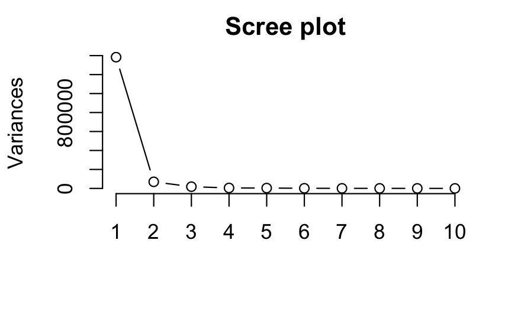

```r
# instead of having the exact x1 x2 values up to x54, we obtain the z values, where z = phi * x


# plot scree
# shows how much of the variation is explatined by each principal component
# type = "l" -line plot
plot(pr.out.ns, type = "l", main = "Scree plot")
```

```
integer(0)
```

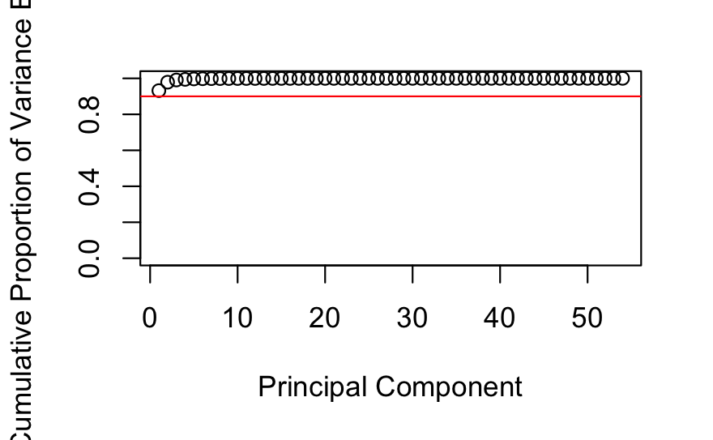

```r
# as observed, first variance is extremely huge, then becomes negligible
# the first principal component is relevant for most of the variables already


# Calculate proportion of variance explained
# plot cumulative prop
pr.var.ns = pr.out.ns$sdev^2

# pve = proportion of variance explained
pve.ns = pr.var.ns / sum(pr.var.ns)


plot(cumsum(pve.ns), xlab = "Principal Component", ylab = "Cumulative Proportion of Variance Explained",
     ylim = c(0,1), type = 'b') + abline(h = 0.9, col = "red")
```

```r
# first PC explanation
pve.ns[1]
```

```
[1] 0.9318276
```

From the `Scree plot’ and the ‘Cumulative Proportion plot’: The first PC actually explains 93% of the variablity.

Let us look at the loadings for each and the PCA scores for the countries. We look at the coefficients of the top and bottom 5. Also we also look at the top and bottom scoring countries for each PC.

- loadings: important characteristics of principal component
- positive and negative sign indicates direction
- large absolute values suggests that it is important (values are relative)

```r
#pr.out.ns$x
#pr.out.ns$rotation

# observe the first two principal component
sp.pc <- data.frame(pr.out.ns$x[, 1:2])

# best and worst performing country based on each principal component
# -ve sign to rank from the best to worst (decreasing order)
sp.pc[order(- sp.pc$PC1), ]
```

|  | PC1 | PC2 |
| --- | --- | --- |
| China | 12715.73833 | -224.084837 |
| United States | 6282.20386 | 80.926516 |
| India | 2694.24724 | -210.921427 |
| Russia | 1900.77590 | 34.519800 |
| Japan | 1031.41589 | 279.281716 |
| Brazil | 841.14835 | 112.938222 |
| Germany | 648.23490 | 250.068165 |
| Iran | 638.46255 | 172.996609 |
| Indonesia | 599.87402 | -77.625476 |
| Korea, Republic of | 471.82937 | 275.320488 |

[output cut: 153 more lines]

```r
sp.pc[order(- sp.pc$PC2), ]
```

|  | PC1 | PC2 |
| --- | --- | --- |
| Switzerland | -230.61371 | 310.311615 |
| Sweden | -222.41506 | 297.838507 |
| Iceland | -276.03257 | 293.674492 |
| Finland | -222.92749 | 290.196502 |
| Norway | -226.15896 | 288.449675 |
| Italy | 161.23905 | 288.268268 |
| Austria | -194.70256 | 283.797814 |
| Spain | 70.86372 | 282.589981 |
| Israel | -192.81018 | 280.659382 |
| Australia | 283.24767 | 279.329249 |

[output cut: 153 more lines]

```r
dim(spi2020)
```

```
[1] 163  54
```

```r
# weights of the variables in each principal component
co.sp.pc <- data.frame(pr.out.ns$rotation[, 1:2])

# highest and lowest weights for principal component 1 and 2 respectively
# look at the top 5 and bottom 5 (we are looking at absolute values)
co.sp.pc[order(- co.sp.pc[, 1]), ][c(1:5, 50:54), ]
```

|  | PC1 | PC2 |
| --- | --- | --- |
| Greenhouse.gas.emissions..total.CO2.equivalents. | 0.997218658 | -0.03355624 |
| Quality.weighted.universities..points. | 0.068416538 | 0.07049700 |
| Access.to.Advanced.Education | 0.003928029 | 0.05931520 |
| Access.to.electricity....of.pop.. | 0.002955186 | 0.08221786 |
| Water.and.Sanitation | 0.002734690 | 0.08931390 |
| Household.air.pollution.attributable.deaths..deaths.100.000. | -0.003362983 | -0.15012659 |
| Unsafe.water..sanitation.and.hygiene.attributable.deaths..per.100.000.pop.. | -0.003571672 | -0.13536896 |
| Premature.deaths.from.non.communicable.diseases..deaths.100.000. | -0.011042437 | -0.45967973 |
| Maternal.mortality.rate..deaths.100.000.live.births. | -0.014093138 | -0.44016285 |
| Deaths.from.infectious.diseases..deaths.100.000. | -0.020127661 | -0.65918710 |

```r
co.sp.pc[order(- co.sp.pc[, 2]), ][c(1:5, 50:54), ]
```

|  | PC1 | PC2 |
| --- | --- | --- |
| Internet.users....of.pop.. | 0.002476401 | 0.09372095 |
| Water.and.Sanitation | 0.002734690 | 0.08931390 |
| Access.to.electricity....of.pop.. | 0.002955186 | 0.08221786 |
| Mobile.telephone.subscriptions..subscriptions.100.people. | 0.002327204 | 0.07987445 |
| Shelter | 0.002214817 | 0.07980050 |
| Unsafe.water..sanitation.and.hygiene.attributable.deaths..per.100.000.pop.. | -0.003571672 | -0.13536896 |
| Household.air.pollution.attributable.deaths..deaths.100.000. | -0.003362983 | -0.15012659 |
| Maternal.mortality.rate..deaths.100.000.live.births. | -0.014093138 | -0.44016285 |
| Premature.deaths.from.non.communicable.diseases..deaths.100.000. | -0.011042437 | -0.45967973 |
| Deaths.from.infectious.diseases..deaths.100.000. | -0.020127661 | -0.65918710 |

We observe that PC1 explains 93% of the variation and moreover PC1 is dominated by Green house gas emission. So countries like China, US, India, Brazil are clustered and dominate together. On the other hand PC2 seems dominated by mortality rates from infectious disease, child birth and other premature deaths.

```r
Stats[1:5,]
```

```
                                     mean median  std.dev
Basic.Human.Needs                76.00644  82.69 18.09972
Foundations.of.Wellbeing         70.32638  71.29 14.30272
Opportunity                      58.26454  56.63 16.01980
Nutrition.and.Basic.Medical.Care 84.30129  91.16 14.81386
Water.and.Sanitation             74.89374  85.77 25.30609
```

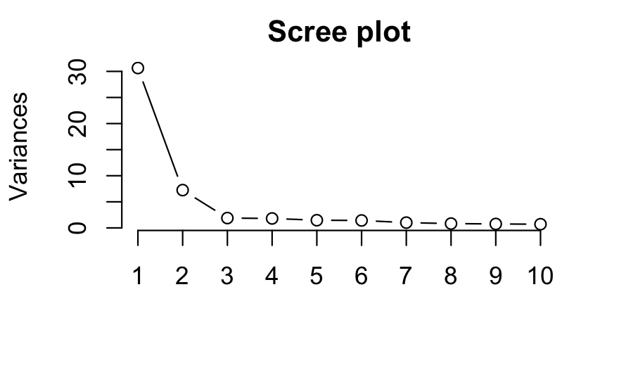

```r
pr.out = prcomp(spi2020, scale = TRUE)
plot(pr.out, type = "l", main = "Scree plot") # as evident, pc1 does not explain as much of the variability
```

```
integer(0)
```

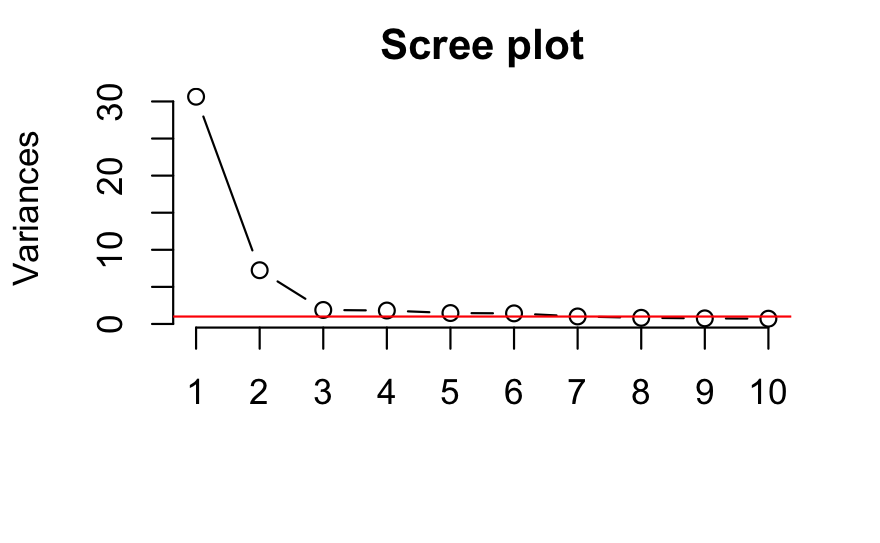

```r
plot(pr.out, type = "l", main = "Scree plot") + abline(h = 1, col = "red")
```

```r
pr.var = pr.out$sdev^2
pr.var
```

```
 [1] 3.064199e+01 7.246006e+00 1.887270e+00 1.811675e+00 1.472157e+00 1.428174e+00 1.013164e+00 8.289534e-01 7.564639e-01 7.098310e-01 5.829749e-01
[12] 5.682025e-01 4.646361e-01 4.514001e-01 3.751002e-01 3.442655e-01 3.403630e-01 3.162698e-01 2.998050e-01 2.346440e-01 2.209638e-01 2.045375e-01
[23] 1.930314e-01 1.723867e-01 1.652674e-01 1.452101e-01 1.362906e-01 1.248117e-01 1.090357e-01 1.036598e-01 8.486582e-02 7.971039e-02 7.001801e-02
[34] 6.006664e-02 5.535986e-02 5.284567e-02 4.271578e-02 3.954332e-02 3.270342e-02 3.084396e-02 2.662021e-02 2.120447e-02 2.034110e-02 1.038257e-02
[45] 9.045395e-03 7.189263e-03 5.690668e-03 2.303976e-03 5.081724e-06 2.669179e-08 2.215541e-08 1.798875e-08 1.367893e-08 6.414484e-09
```

```r
pve = pr.var/sum(pr.var)
pve
```

```
 [1] 5.674443e-01 1.341853e-01 3.494944e-02 3.354953e-02 2.726217e-02 2.644768e-02 1.876229e-02 1.535099e-02 1.400859e-02 1.314502e-02 1.079583e-02
[12] 1.052227e-02 8.604371e-03 8.359260e-03 6.946299e-03 6.375287e-03 6.303018e-03 5.856848e-03 5.551945e-03 4.345260e-03 4.091923e-03 3.787731e-03
[23] 3.574655e-03 3.192346e-03 3.060508e-03 2.689077e-03 2.523900e-03 2.311329e-03 2.019180e-03 1.919627e-03 1.571589e-03 1.476118e-03 1.296630e-03
[34] 1.112345e-03 1.025183e-03 9.786235e-04 7.910329e-04 7.322836e-04 6.056189e-04 5.711844e-04 4.929669e-04 3.926753e-04 3.766871e-04 1.922698e-04
[45] 1.675073e-04 1.331345e-04 1.053827e-04 4.266621e-05 9.410600e-08 4.942924e-10 4.102854e-10 3.331250e-10 2.533134e-10 1.187867e-10
```

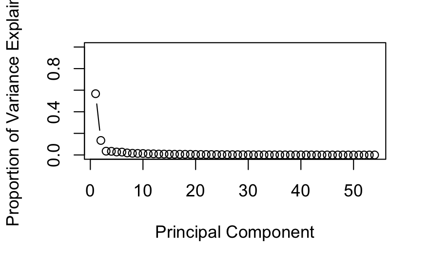

```r
plot(pve, xlab = "Principal Component", ylab = "Proportion of Variance Explained", ylim = c(0,1), type = 'b')
```

```
integer(0)
```

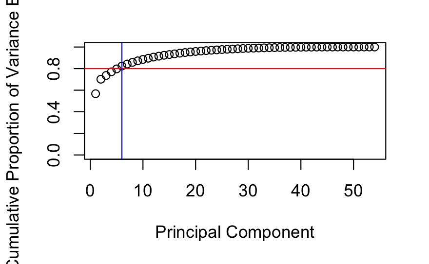

```r
plot(cumsum(pve), xlab ="Principal Component", ylab = "Cumulative Proportion of Variance Explained", ylim = c(0,1), type = 'b')  + abline(h = 0.8, col = "red") + abline(v = 6, col = "blue")
```

```r
# with just the first 6 PCs, able to explain 80% of the variability in data


# Which components and which country?
# determine which countries are ranked well in PC1 and PC2 respectively
# which indicators have the most loadings in PC1 and PC2 respectively
sp4 <- data.frame(pr.out$x[, 1:4])
sp4[order(- sp4$PC1), ]
```

|  | PC1 | PC2 | PC3 | PC4 |
| --- | --- | --- | --- | --- |
| Norway | 8.645218370 | -2.54976925 | -0.382451638 | -0.92591449 |
| Switzerland | 8.532802087 | -1.97772651 | -0.017725472 | -0.69921795 |
| Denmark | 8.512089543 | -2.54123727 | 0.077977589 | -0.27887617 |
| Sweden | 8.360127703 | -2.45000470 | -0.238627096 | -0.68693418 |
| Finland | 8.274310193 | -2.57454808 | -0.225952872 | -0.66823147 |
| Iceland | 8.134080264 | -1.56394636 | -1.077423591 | -0.93540471 |
| Canada | 8.014893145 | -1.99819471 | 0.441784246 | -1.00585604 |
| Japan | 7.929151555 | -0.94698561 | 1.769709919 | -1.81245706 |
| New Zealand | 7.912629077 | -2.38248071 | -0.333850417 | -0.88953097 |
| Netherlands | 7.906187368 | -1.71866001 | -0.060190653 | -0.74162022 |

[output cut: 153 more lines]

```r
cosp4 <- data.frame(pr.out$rotation[, 1:4])
cosp4[order(- cosp4[, 1]), ]
```

|  | PC1 | PC2 | PC3 | PC4 |
| --- | --- | --- | --- | --- |
| Foundations.of.Wellbeing | 0.17588076 | -0.0231531079 | -0.064215820 | -0.0812707693 |
| Basic.Human.Needs | 0.17195776 | 0.0988352411 | -0.023902741 | 0.0251349207 |
| Access.to.essential.services...0.none..100.full.coverage. | 0.17177645 | 0.0655314772 | 0.005287744 | -0.0680726476 |
| Opportunity | 0.16934968 | -0.1056049514 | 0.079998428 | 0.0343222872 |
| Health.and.Wellness | 0.16637512 | 0.0274896556 | -0.012896378 | -0.1535854398 |
| Access.to.Information.and.Communications | 0.16633731 | -0.0003931468 | 0.103700719 | 0.0496290834 |
| Personal.Freedom.and.Choice | 0.16623175 | 0.0377355915 | 0.007584147 | 0.0113613616 |
| Nutrition.and.Basic.Medical.Care | 0.16538529 | 0.1224542099 | -0.020612833 | 0.0221813189 |
| Water.and.Sanitation | 0.16427357 | 0.1313893633 | -0.037749294 | 0.0144075955 |
| Shelter | 0.16287627 | 0.1207507845 | -0.015526038 | 0.0293548458 |

[output cut: 44 more lines]

```r
NA
NA
```

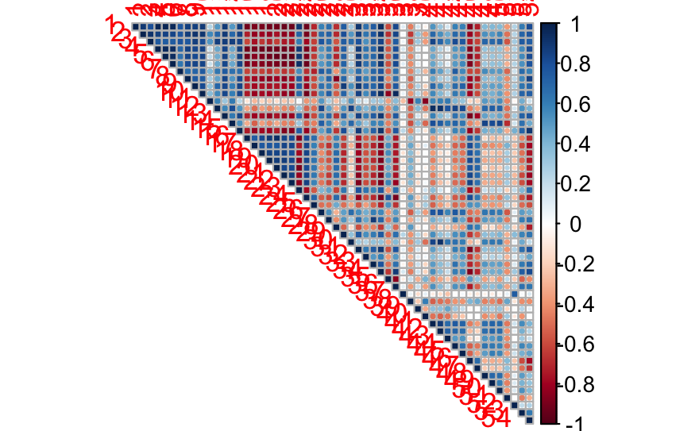

Now, we can go back to the documentation of the data and see that the primary components here are not the core metrics computed. There are three big dimensions: 1. Basic Human Needs 2. Foundations of Well-being 3. Opportunity

The SPI is an average of these three quantities which are again averages of four different quantities each. We remove this to have the core data to study.

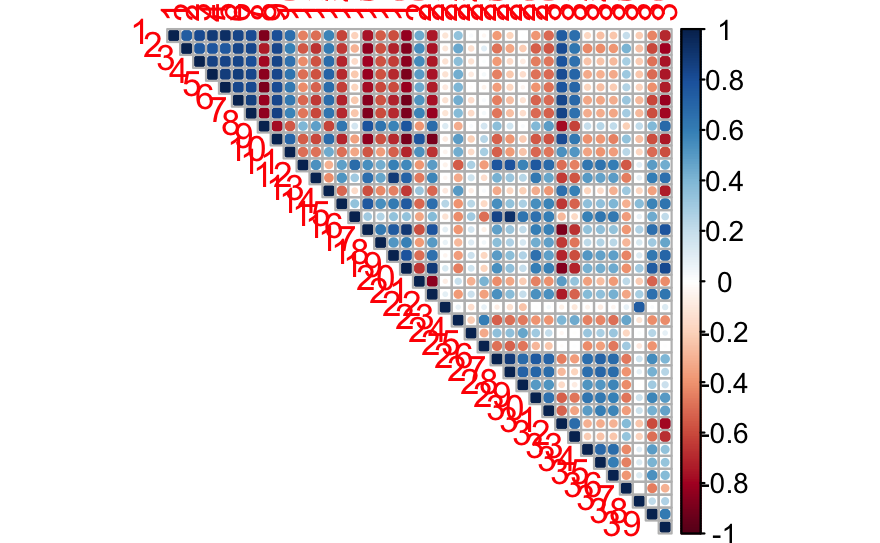

Now we conduct a PCA. What we observe is that the PC1 explains 50.0% PC2 explains 14.2% PC3 explains 4.6%  
PC4 explains 3.7%

```
integer(0)
```

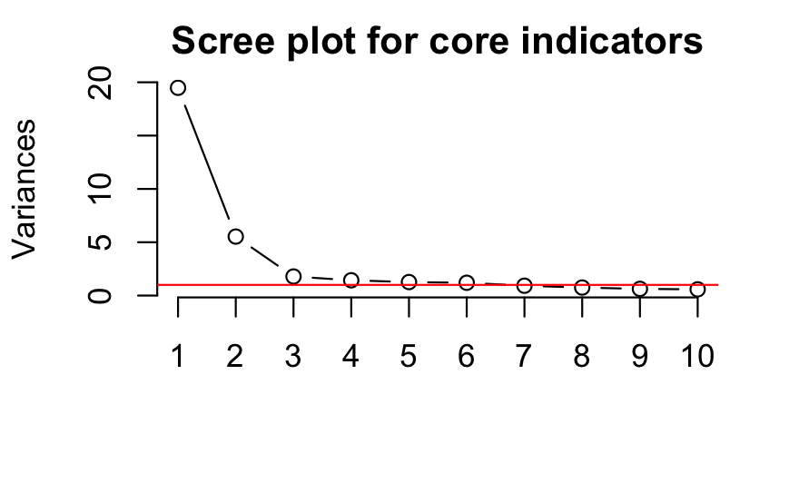

```r
pr.out.core <- prcomp(spi2020core, scale = TRUE)
# pr.out.core
#
plot(pr.out.core, type = "l", main = "Scree plot for core indicators") + abline(h = 1, col = "red")
```

```r
pr.var.core = pr.out.core$sdev^2
#pr.var.core
pve.core = pr.var.core / sum(pr.var.core)
pve.core
```

```
 [1] 0.4995375309 0.1418431236 0.0458570024 0.0367125851 0.0324533884 0.0307786779 0.0236679525 0.0192697154 0.0160904297 0.0149292014
[11] 0.0132099724 0.0127548837 0.0109588234 0.0100919687 0.0091445464 0.0084845289 0.0080622265 0.0076195313 0.0069743322 0.0057231996
[21] 0.0051095331 0.0045197027 0.0043852010 0.0037644713 0.0036404605 0.0035837786 0.0029618049 0.0028930647 0.0023884956 0.0021216353
[31] 0.0019817646 0.0018434924 0.0014749256 0.0012593072 0.0011036603 0.0009343887 0.0007930752 0.0006008931 0.0004767247
```

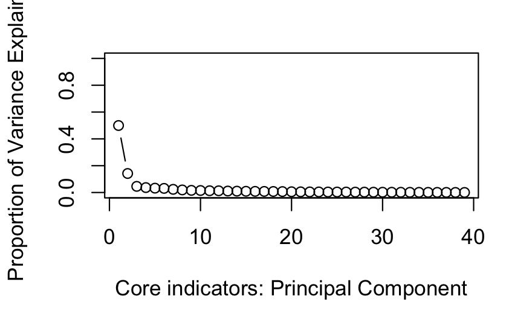

```r
plot(pve.core, xlab = "Core indicators: Principal Component", ylab = "Proportion of Variance Explained", ylim = c(0,1), type = 'b')
```

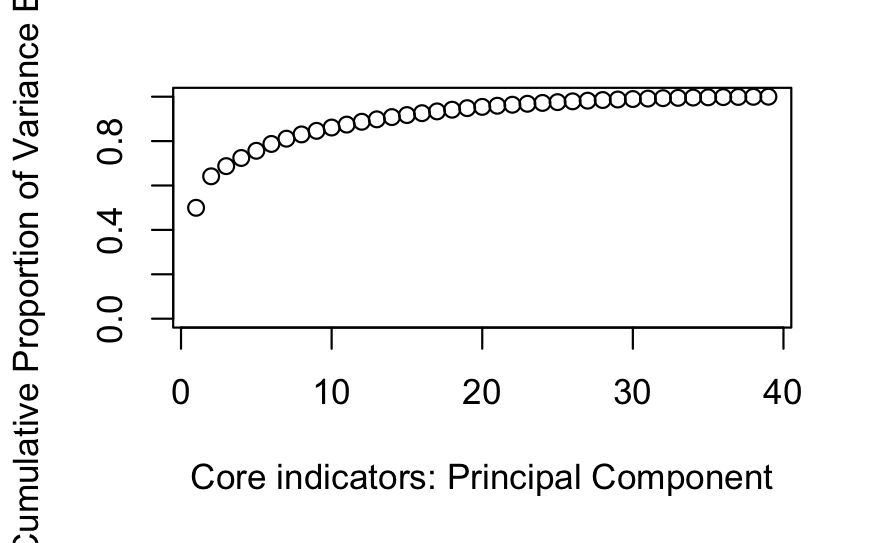

```r
plot(cumsum(pve.core), xlab = "Core indicators: Principal Component", ylab = "Cumulative Proportion of Variance Explained", ylim = c(0, 1), type = 'b')
```

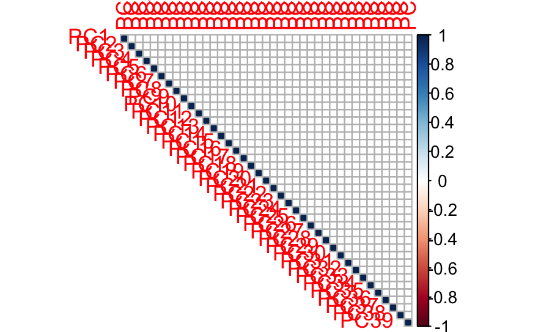

PC1: Foundations of well-being, health and wellness (+), … Basic human needs: lack of water and sanitation/shelter (-) PC2: Opportunity, lack of personal rights (-), … Foundations of well-being, environment quality (+) PC3: …

Now we do some plotting

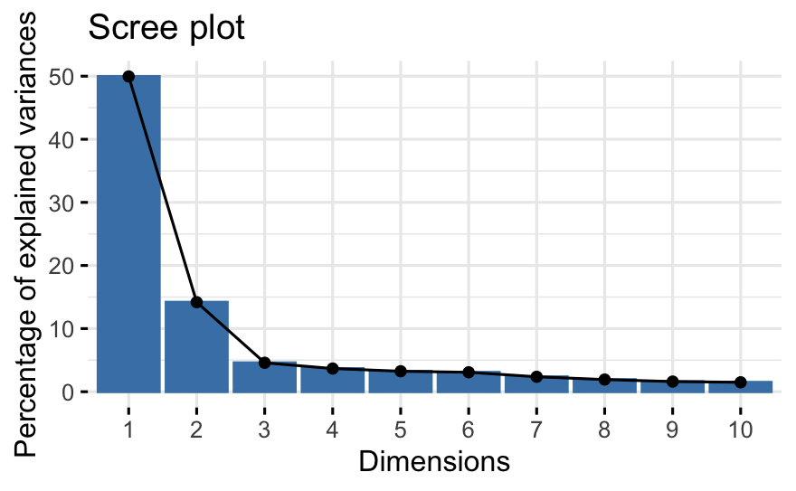

```r
library(factoextra)

# scree plot
fviz_eig(pr.out.core)
```

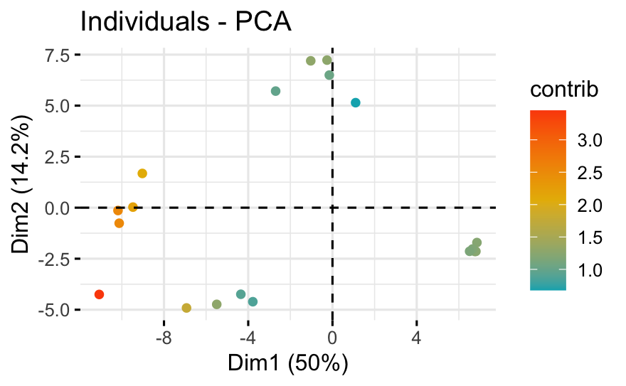

```r
# gives individual countries (elements) plotted against two selected principal components
# selected PC1 and PC2 in this case, then PC3 and PC4
fviz_pca_ind(pr.out.core, labelsize=3,
            col.ind = "contrib", # Color by the quality of representation
            gradient.cols = c("#00AFBB", "#E7B800", "#FC4E07"),
            geom = c("point","text"),
            #select.ind = list(cos2 = 30),
            select.ind = list(name = c(topbotind1, topbotind2)),
            repel = TRUE     # Avoid text overlapping
            )
```

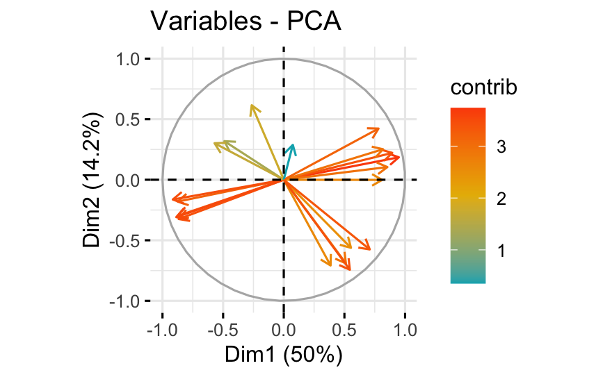

```r
# size of loadings of PC1 and PC2
fviz_pca_var(pr.out.core, labelsize=3,
            col.var = "contrib", # Color by contributions to the PC
            gradient.cols = c("#00AFBB", "#E7B800", "#FC4E07"),
            select.var = list(name = c(topbotPC1, topbotPC2)),
            repel = TRUE     # Avoid text overlapping
            )
```

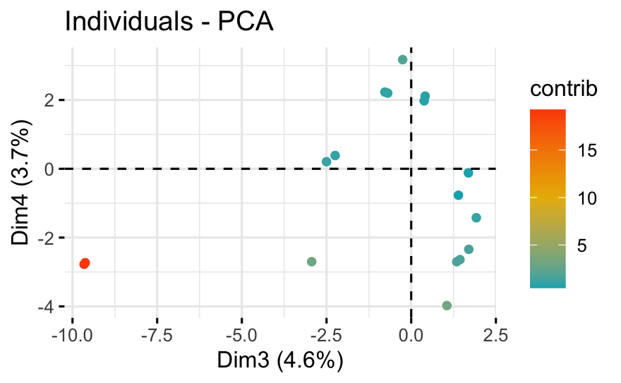

```r
fviz_pca_ind(pr.out.core, labelsize=3,
            col.ind = "contrib", # Color by the quality of representation
            axes = c(3,4),
            gradient.cols = c("#00AFBB", "#E7B800", "#FC4E07"),
            geom = c("point","text"),
            #select.ind = list(cos2 = 30),
            #theme(text = element_text(size = 2)),
            select.ind = list(name = c(topbotind3, topbotind4)),
            repel = TRUE     # Avoid text overlapping
            )
```

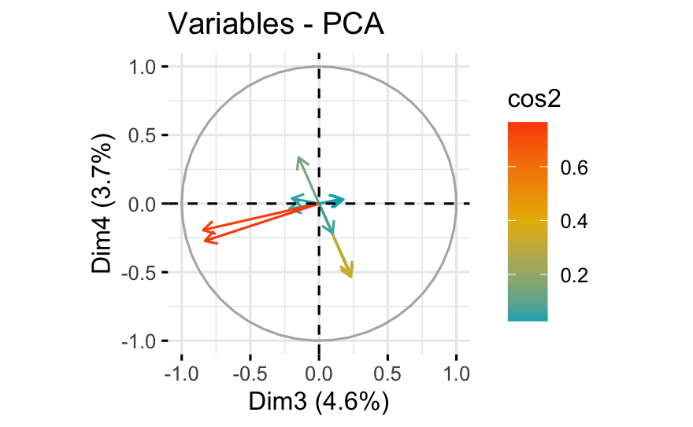

```r
fviz_pca_var(pr.out.core, labelsize=3,
            col.var = "cos2", # Color by contributions to the PC
            gradient.cols = c("#00AFBB", "#E7B800", "#FC4E07"),
            axes = c(3, 4),
            select.var = list(name = c(topbotPC3, topbotPC4)),
            repel = TRUE     # Avoid text overlapping
            )
```

```r
NA
NA
```

Can we come up with a rank based on the PCAs. We can just use the first PCA. In general it is not suggested that we add scores from different PCAs … but if we still go ahead and do that for one more.

```r
# compare PC1 between the social progress index and our own PCA
spi_ae <- data.frame(sp4.core[,1]) # -sp4.core[,2])#-sp4.core[,3]+sp4.core[,4])
rownames(spi_ae) <- rownames(sp4.core)
spi_ae$rank <- rank(-spi_ae)
spi_ae$spirank <- spirank
colnames(spi_ae) <- c("Score","Rank AE","Rank SPI")
spi_ae[order(spi_ae[,2]),]
```

|  | Score | Rank AE | Rank SPI |
| --- | --- | --- | --- |
| Switzerland | 6.858366016 | 1 | 6 |
| Norway | 6.808963943 | 2 | 1 |
| Denmark | 6.758296779 | 3 | 2 |
| Sweden | 6.648665147 | 4 | 5 |
| Finland | 6.511241009 | 5 | 3 |
| Iceland | 6.417116916 | 6 | 9 |
| Luxembourg | 6.400102729 | 7 | 14 |
| Japan | 6.300462310 | 8 | 13 |
| Canada | 6.227915882 | 9 | 7 |
| Germany | 6.215779083 | 10 | 11 |

[output cut: 153 more lines]

###### End of PCA Analysis for Social Progress data.